# Working with Vectors

# Creating and Operating on Vectors

Create a vector `names` that contains your name and the names of 2 people next to you. Print the vector.

```r
names <- c("Christain", "Binx", "Tyler")
print(names)
```

```
[1] "Christain" "Binx"      "Tyler"
```

Use the colon operator `:` to create a vector `n` of numbers from 10 to 49

```r
n <- 10:49
n
```

```
 [1] 10 11 12 13 14 15 16 17 18 19 20 21 22 23 24 25 26 27 28 29 30 31 32 33 34 35 36 37 38 39 40 41 42 43 44 45 46 47 48 49
```

Use the `length()` function to get the number of elements in `n`

```r
length(n)
```

```
[1] 40
```

Add 1 to each element in `n` and print the result

```r
n+1
```

```
 [1] 11 12 13 14 15 16 17 18 19 20 21 22 23 24 25 26 27 28 29 30 31 32 33 34 35 36 37 38 39 40 41 42 43 44 45 46 47 48 49 50
```

Create a vector `m` that contains the numbers 10 to 1 (in that order). Hint: use the `seq()` function

```r
m <- seq(10,1)
m
```

```
 [1] 10  9  8  7  6  5  4  3  2  1
```

Subtract `m` from `n`. Note the recycling!

```r
n-m
```

```
 [1]  0  2  4  6  8 10 12 14 16 18 10 12 14 16 18 20 22 24 26 28 20 22 24 26 28 30 32 34 36 38 30 32 34 36 38 40 42 44 46 48
```

Use the `seq()` function to produce a range of numbers from -5 to 10 in `0.1` increments. Store it in a variable `x_range`

```r
x_range <- seq(-5,10,0.1)
x_range
```

```
  [1] -5.0 -4.9 -4.8 -4.7 -4.6 -4.5 -4.4 -4.3 -4.2 -4.1 -4.0 -3.9 -3.8 -3.7 -3.6 -3.5 -3.4 -3.3 -3.2 -3.1 -3.0 -2.9 -2.8 -2.7 -2.6 -2.5 -2.4 -2.3
 [29] -2.2 -2.1 -2.0 -1.9 -1.8 -1.7 -1.6 -1.5 -1.4 -1.3 -1.2 -1.1 -1.0 -0.9 -0.8 -0.7 -0.6 -0.5 -0.4 -0.3 -0.2 -0.1  0.0  0.1  0.2  0.3  0.4  0.5
 [57]  0.6  0.7  0.8  0.9  1.0  1.1  1.2  1.3  1.4  1.5  1.6  1.7  1.8  1.9  2.0  2.1  2.2  2.3  2.4  2.5  2.6  2.7  2.8  2.9  3.0  3.1  3.2  3.3
 [85]  3.4  3.5  3.6  3.7  3.8  3.9  4.0  4.1  4.2  4.3  4.4  4.5  4.6  4.7  4.8  4.9  5.0  5.1  5.2  5.3  5.4  5.5  5.6  5.7  5.8  5.9  6.0  6.1
[113]  6.2  6.3  6.4  6.5  6.6  6.7  6.8  6.9  7.0  7.1  7.2  7.3  7.4  7.5  7.6  7.7  7.8  7.9  8.0  8.1  8.2  8.3  8.4  8.5  8.6  8.7  8.8  8.9
[141]  9.0  9.1  9.2  9.3  9.4  9.5  9.6  9.7  9.8  9.9 10.0
```

Create a vector `sin_wave` by calling the `sin()` function on each element in `x_range`.

```r
sin_wave <- sin(x_range)
sin_wave
```

```
  [1]  0.95892427  0.98245261  0.99616461  0.99992326  0.99369100  0.97753012  0.95160207  0.91616594  0.87157577  0.81827711  0.75680250
 [12]  0.68776616  0.61185789  0.52983614  0.44252044  0.35078323  0.25554110  0.15774569  0.05837414 -0.04158066 -0.14112001 -0.23924933
 [23] -0.33498815 -0.42737988 -0.51550137 -0.59847214 -0.67546318 -0.74570521 -0.80849640 -0.86320937 -0.90929743 -0.94630009 -0.97384763
 [34] -0.99166481 -0.99957360 -0.99749499 -0.98544973 -0.96355819 -0.93203909 -0.89120736 -0.84147098 -0.78332691 -0.71735609 -0.64421769
 [45] -0.56464247 -0.47942554 -0.38941834 -0.29552021 -0.19866933 -0.09983342  0.00000000  0.09983342  0.19866933  0.29552021  0.38941834
 [56]  0.47942554  0.56464247  0.64421769  0.71735609  0.78332691  0.84147098  0.89120736  0.93203909  0.96355819  0.98544973  0.99749499
 [67]  0.99957360  0.99166481  0.97384763  0.94630009  0.90929743  0.86320937  0.80849640  0.74570521  0.67546318  0.59847214  0.51550137
 [78]  0.42737988  0.33498815  0.23924933  0.14112001  0.04158066 -0.05837414 -0.15774569 -0.25554110 -0.35078323 -0.44252044 -0.52983614
 [89] -0.61185789 -0.68776616 -0.75680250 -0.81827711 -0.87157577 -0.91616594 -0.95160207 -0.97753012 -0.99369100 -0.99992326 -0.99616461
[100] -0.98245261 -0.95892427 -0.92581468 -0.88345466 -0.83226744 -0.77276449 -0.70554033 -0.63126664 -0.55068554 -0.46460218 -0.37387666
[111] -0.27941550 -0.18216250 -0.08308940  0.01681390  0.11654920  0.21511999  0.31154136  0.40484992  0.49411335  0.57843976  0.65698660
[122]  0.72896904  0.79366786  0.85043662  0.89870810  0.93799998  0.96791967  0.98816823  0.99854335  0.99894134  0.98935825  0.96988981
[133]  0.94073056  0.90217183  0.85459891  0.79848711  0.73439710  0.66296923  0.58491719  0.50102086  0.41211849  0.31909836  0.22288991
[144]  0.12445442  0.02477543 -0.07515112 -0.17432678 -0.27176063 -0.36647913 -0.45753589 -0.54402111
```

Create a vector `cos_wave` by calling the `cos()` function on each element in `x_range`.

```r
cos_wave <- cos(x_range)
cos_wave
```

```
  [1]  0.28366219  0.18651237  0.08749898 -0.01238866 -0.11215253 -0.21079580 -0.30733287 -0.40079917 -0.49026082 -0.57482395 -0.65364362
 [12] -0.72593230 -0.79096771 -0.84810003 -0.89675842 -0.93645669 -0.96679819 -0.98747977 -0.99829478 -0.99913515 -0.98999250 -0.97095817
 [23] -0.94222234 -0.90407214 -0.85688875 -0.80114362 -0.73739372 -0.66627602 -0.58850112 -0.50484610 -0.41614684 -0.32328957 -0.22720209
 [34] -0.12884449 -0.02919952  0.07073720  0.16996714  0.26749883  0.36235775  0.45359612  0.54030231  0.62160997  0.69670671  0.76484219
 [45]  0.82533561  0.87758256  0.92106099  0.95533649  0.98006658  0.99500417  1.00000000  0.99500417  0.98006658  0.95533649  0.92106099
 [56]  0.87758256  0.82533561  0.76484219  0.69670671  0.62160997  0.54030231  0.45359612  0.36235775  0.26749883  0.16996714  0.07073720
 [67] -0.02919952 -0.12884449 -0.22720209 -0.32328957 -0.41614684 -0.50484610 -0.58850112 -0.66627602 -0.73739372 -0.80114362 -0.85688875
 [78] -0.90407214 -0.94222234 -0.97095817 -0.98999250 -0.99913515 -0.99829478 -0.98747977 -0.96679819 -0.93645669 -0.89675842 -0.84810003
 [89] -0.79096771 -0.72593230 -0.65364362 -0.57482395 -0.49026082 -0.40079917 -0.30733287 -0.21079580 -0.11215253 -0.01238866  0.08749898
[100]  0.18651237  0.28366219  0.37797774  0.46851667  0.55437434  0.63469288  0.70866977  0.77556588  0.83471278  0.88551952  0.92747843
[111]  0.96017029  0.98326844  0.99654210  0.99985864  0.99318492  0.97658763  0.95023259  0.91438315  0.86939749  0.81572510  0.75390225
[122]  0.68454667  0.60835131  0.52607752  0.43854733  0.34663532  0.25125984  0.15337386  0.05395542 -0.04600213 -0.14550003 -0.24354415
[133] -0.33915486 -0.43137684 -0.51928865 -0.60201190 -0.67872005 -0.74864665 -0.81109301 -0.86543521 -0.91113026 -0.94772160 -0.97484362
[144] -0.99222533 -0.99969304 -0.99717216 -0.98468786 -0.96236488 -0.93042627 -0.88919115 -0.83907153
```

Create a vector `wave` by multiplying `sin_wave` and `cos_wave` together, then adding `sin_wave` to the product

```r
wave <- sin_wave * cos_wave + sin_wave
wave
```

```
  [1]  1.230935e+00  1.165692e+00  1.083328e+00  9.875355e-01  8.822460e-01  7.714709e-01  6.591435e-01  5.489674e-01  4.442763e-01  3.479118e-01
 [11]  2.621234e-01  1.884945e-01  1.278981e-01  8.048209e-02  4.568651e-02  2.228993e-02  8.484426e-03  1.975012e-03  9.954100e-05 -3.596102e-05
 [21] -1.412259e-03 -6.948240e-03 -1.935483e-02 -4.099764e-02 -7.377404e-02 -1.190100e-01 -1.773809e-01 -2.488597e-01 -3.326954e-01 -4.274215e-01
 [31] -5.308962e-01 -6.403711e-01 -7.525874e-01 -8.638943e-01 -9.703865e-01 -1.068055e+00 -1.152944e+00 -1.221309e+00 -1.269771e+00 -1.295456e+00
 [41] -1.296120e+00 -1.270251e+00 -1.217143e+00 -1.136943e+00 -1.030662e+00 -9.001610e-01 -7.480964e-01 -5.778414e-01 -3.933785e-01 -1.991681e-01
 [51]  0.000000e+00  1.991681e-01  3.933785e-01  5.778414e-01  7.480964e-01  9.001610e-01  1.030662e+00  1.136943e+00  1.217143e+00  1.270251e+00
 [61]  1.296120e+00  1.295456e+00  1.269771e+00  1.221309e+00  1.152944e+00  1.068055e+00  9.703865e-01  8.638943e-01  7.525874e-01  6.403711e-01
 [71]  5.308962e-01  4.274215e-01  3.326954e-01  2.488597e-01  1.773809e-01  1.190100e-01  7.377404e-02  4.099764e-02  1.935483e-02  6.948240e-03
 [81]  1.412259e-03  3.596102e-05 -9.954100e-05 -1.975012e-03 -8.484426e-03 -2.228993e-02 -4.568651e-02 -8.048209e-02 -1.278981e-01 -1.884945e-01
 [91] -2.621234e-01 -3.479118e-01 -4.442763e-01 -5.489674e-01 -6.591435e-01 -7.714709e-01 -8.822460e-01 -9.875355e-01 -1.083328e+00 -1.165692e+00
[101] -1.230935e+00 -1.275752e+00 -1.297368e+00 -1.293655e+00 -1.263233e+00 -1.205535e+00 -1.120856e+00 -1.010350e+00 -8.760165e-01 -7.206392e-01
[111] -5.477020e-01 -3.612771e-01 -1.658915e-01  3.362542e-02  2.323041e-01  4.252035e-01  6.075781e-01  7.750379e-01  9.236943e-01  1.050288e+00
[121]  1.152290e+00  1.227982e+00  1.276497e+00  1.297832e+00  1.292834e+00  1.263144e+00  1.211119e+00  1.139727e+00  1.052420e+00  9.529879e-01
[131]  8.454066e-01  7.336788e-01  6.216772e-01  5.129958e-01  4.108154e-01  3.177884e-01  2.359471e-01  1.666395e-01  1.104949e-01  6.741977e-02
[141]  3.662486e-02  1.668195e-02  5.607103e-03  9.675926e-04  7.605014e-06 -2.125156e-04 -2.669317e-03 -1.022774e-02 -2.549732e-02 -5.069903e-02
[151] -8.754849e-02
```

Use the `plot()` function to plot your `wave`!

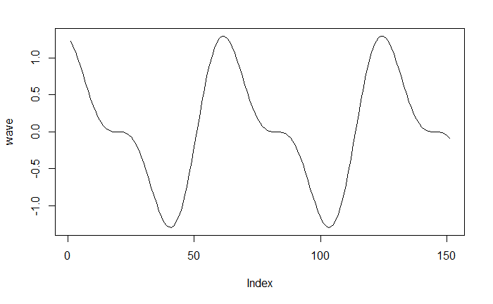

```r
plot(wave, type = "l")
```

# Indexing and Filtering Vectors

Create a vector `lotto_numbers` that contains the numbers 8, 26, 7, 20, 9, 0, 10

```r
lotto_numbers <- c(8, 26, 7, 20, 9, 0, 10)
lotto_numbers
```

```
[1]  8 26  7 20  9  0 10
```

Create a vector `prefix` that has the first three elements of `lotto_numbers`

```r
prefix <- lotto_numbers[1:3]
prefix
```

```
[1]  8 26  7
```

Create a vector `small` that has the values of `lotto_numbers` that are less than or equal to 10

```r
small <- lotto_numbers[lotto_numbers<=10]
small
```

```
[1]  8  7  9  0 10
```

Create a vector `large` that has the values of `lotto_numbers` that are strictly greater than 10

```r
large <- lotto_numbers[lotto_numbers>10]
large
```

```
[1] 26 20
```

Replace the values in `lotto_numbers` that are larger than 5 with the number 100

```r
lotto_numbers[lotto_numbers>5] <- 100
lotto_numbers
```

```
[1] 100 100 100 100 100   0 100
```

Replace every odd-numbered value in `lotto_numbers` with the number 0

```r
lotto_numbers[lotto_numbers %% 2 == 1] <- 0
lotto_numbers
```

```
[1] 100 100 100 100 100   0 100
```